# Presentation

6/24/2019

## Case Study 1

-Bitterness & Concentration Across US Breweries

-SMU - DDS 6306

-Mombers:

Fabio Savorgnan

Jeremy Otsap

## Overview

-Beer Data Set

Name: Name of the beer. Beer_ID: Unique identifier of the beer. ABV: Alcohol by volume of the beer. IBU: International Bitterness Units of the beer. Brewery_ID: Brewery id associated with the beer. Style: Style of the beer. Ounces: Ounces of beer.

-Brewery Data Set

Brew_ID: Unique identifier of the brewery. Name: Name of the brewery. City: City where the brewery is located. State: U.S. State where the brewery is located.

## Introduction: Given the datasets Beer and Brews, we want to know

-Where our headquarters should be?

-What style and name of beer would appeal to the widest audience?

-What ABV and IBU should be used for the production of beers?

## Combined Data Set

```
##   Brew_ID       Brewery_Name        City State     Beer_Name Beer_ID   ABV
## 1       1 NorthGate Brewing  Minneapolis    MN       Pumpion    2689 0.060
## 2       1 NorthGate Brewing  Minneapolis    MN    Stronghold    2688 0.060
## 3       1 NorthGate Brewing  Minneapolis    MN   Parapet ESB    2687 0.056
## 4       1 NorthGate Brewing  Minneapolis    MN  Get Together    2692 0.045
## 5       1 NorthGate Brewing  Minneapolis    MN Maggie's Leap    2691 0.049
## 6       1 NorthGate Brewing  Minneapolis    MN    Wall's End    2690 0.048
##   IBU                               Style Ounces
## 1  38                         Pumpkin Ale     16
## 2  25                     American Porter     16
## 3  47 Extra Special / Strong Bitter (ESB)     16
## 4  50                        American IPA     16
## 5  26                  Milk / Sweet Stout     16
## 6  19                   English Brown Ale     16
```

```
##      Brew_ID                  Brewery_Name          City State
## 2405     556         Ukiah Brewing Company         Ukiah    CA
## 2406     557       Butternuts Beer and Ale Garrattsville    NY
## 2407     557       Butternuts Beer and Ale Garrattsville    NY
## 2408     557       Butternuts Beer and Ale Garrattsville    NY
## 2409     557       Butternuts Beer and Ale Garrattsville    NY
## 2410     558 Sleeping Lady Brewing Company     Anchorage    AK
##                      Beer_Name Beer_ID   ABV IBU                   Style
## 2405             Pilsner Ukiah      98 0.055  NA         German Pilsener
## 2406         Porkslap Pale Ale      49 0.043  NA American Pale Ale (APA)
## 2407           Snapperhead IPA      51 0.068  NA            American IPA
## 2408         Moo Thunder Stout      50 0.049  NA      Milk / Sweet Stout
## 2409  Heinnieweisse Weissebier      52 0.049  NA              Hefeweizen
## 2410 Urban Wilderness Pale Ale      30 0.049  NA        English Pale Ale
##      Ounces
## 2405     12
## 2406     12
## 2407     12
## 2408     12
## 2409     12
## 2410     12
```

## Missing values

-Alcohol by Volume – 62 of 2410 entries were missing. ~2.57%

-International Bitterness – 1005 of 2410 entries were missing. ~41.7%

-NOTE: Bitterness data not available for South Dakota

```
##      Brew_ID Brewery_Name         City        State    Beer_Name
##            0            0            0            0            0
##      Beer_ID          ABV          IBU        Style       Ounces
##            0           62         1005            0            0
```

## Breweries Per State

Top 4 States: -Colorado -California -Michigan -Oregon

Bottom 4 States: -DC -South Dakota -North Dakota -West Virginia

[figure not shown]

## Median Alcohol & Bitterness By State

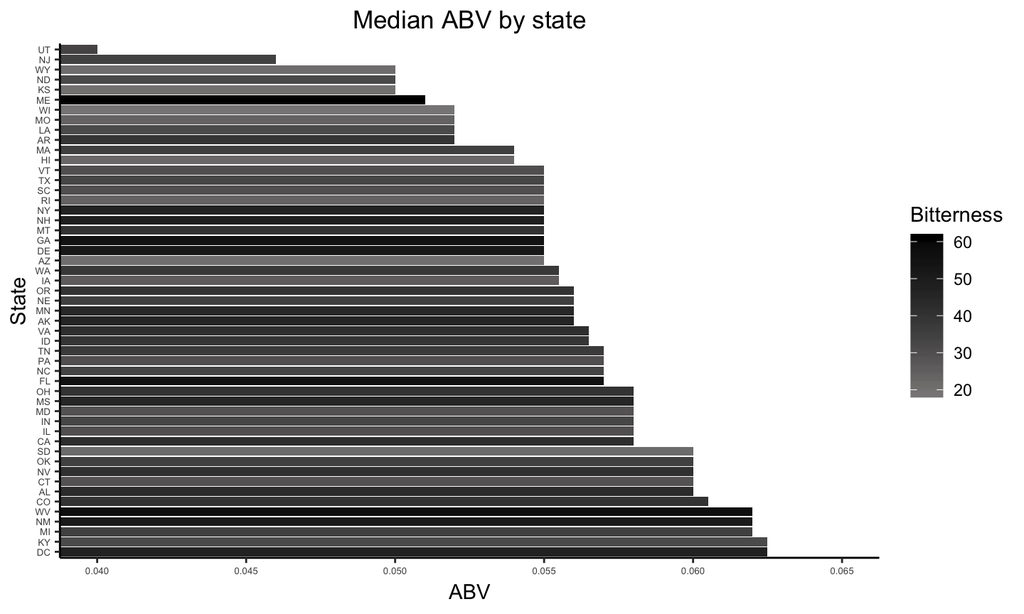

## The top 5 state with more alcohol content

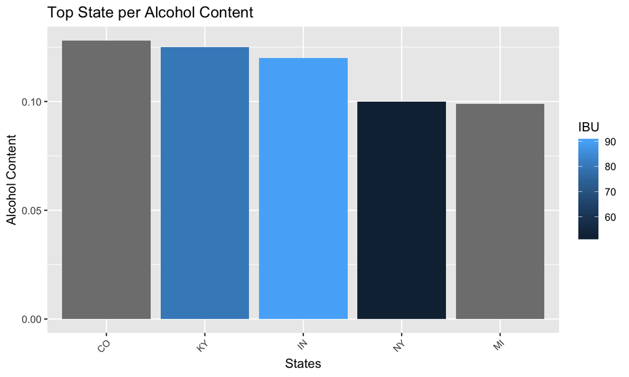

## The top 5 state with the most bitter beer

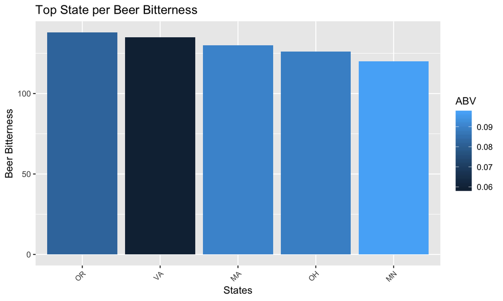

## The bottom 5 lowest state with alcohol content

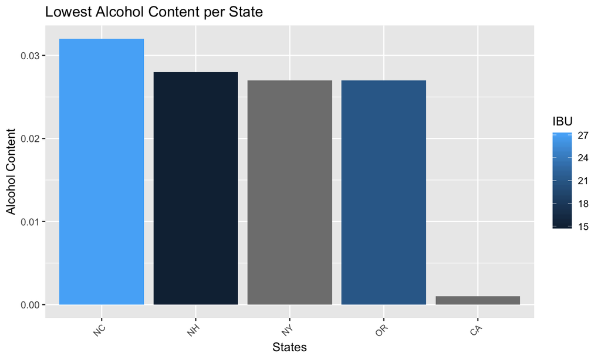

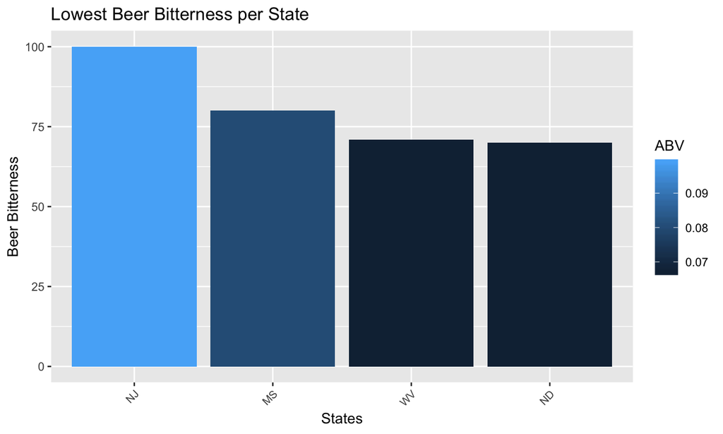

## Alcohol Content

Highest Alcohol Beer

-Lee Hill Series Vol. 5 - Belgian Style Quadrupel Ale

-12.8% AB

-Colorado

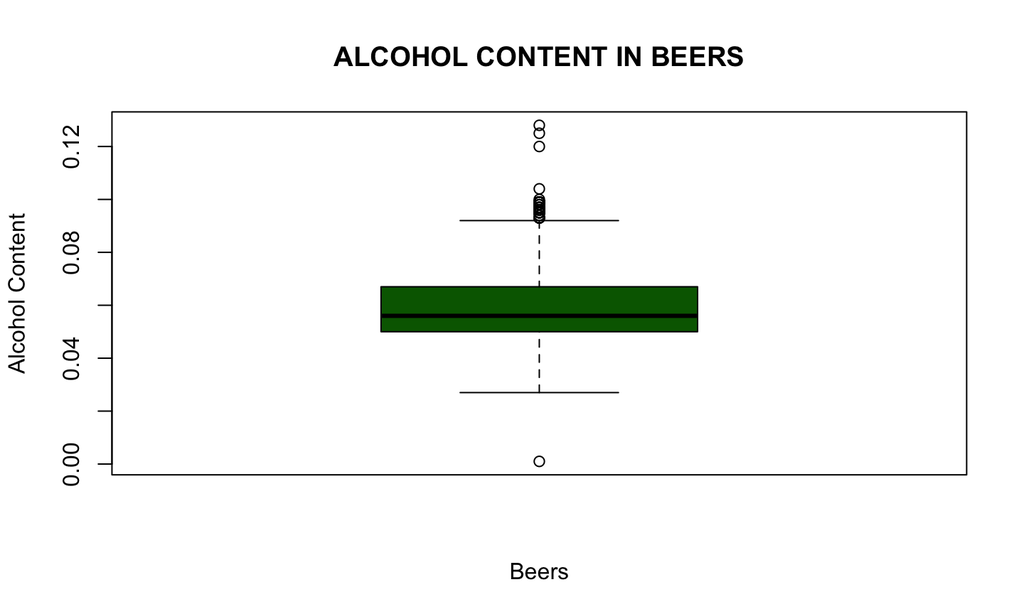

## Highest Bitterness Beer

-Bitter Bitch Imperial IPA

-IBU of 138

-Oregon

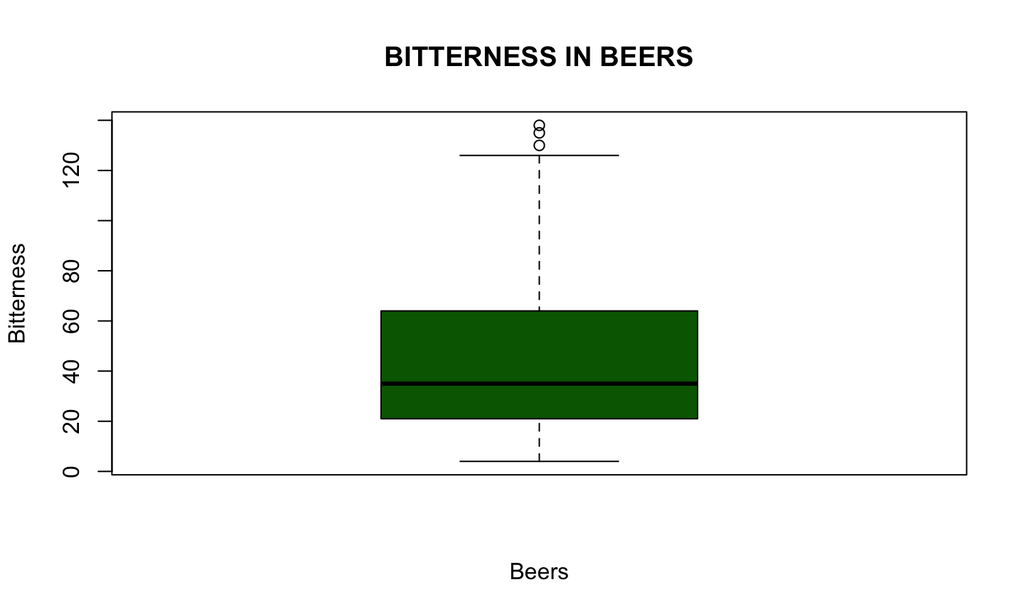

## Correlation Between Bitterness & Alcohol Content

-Correlation: 67.06%

-R-squared: 44.97%

-This shows a moderate correlation between the bitterness and strength of the alcohol. About 45% of the bitterness of a particular beer is accounted for by its alcohol content

## Plot of the Relationship Between Bitterness & Alcohol Content

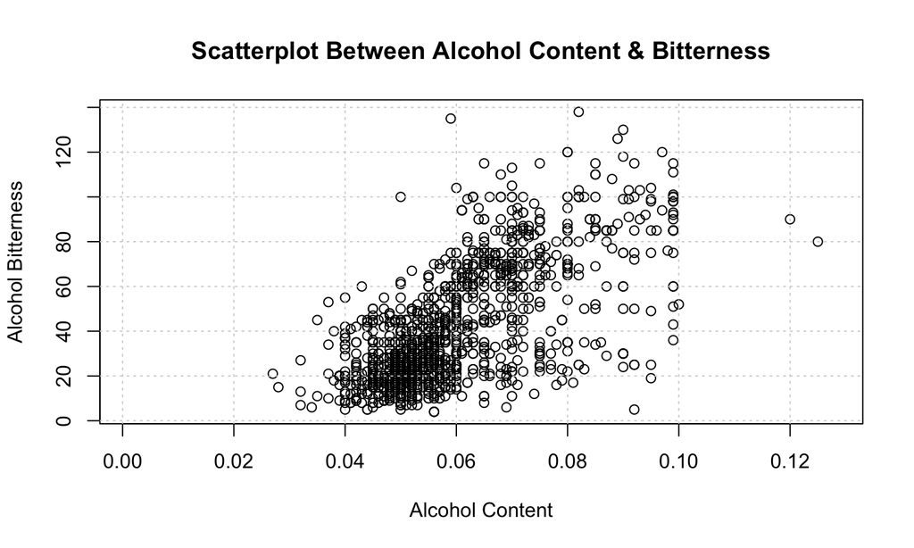

## Additional Analysis : 2018 Census Data on https://www.census.gov

-Examining correlation between state population and number of breweries

-There appears to be a moderate correlation of 62.1%

-The R-squared value is 38.57% which means that almost 39% of the brewery density can be explained by the respective state’s total population

## Plotting the correlation between state population and number of breweries

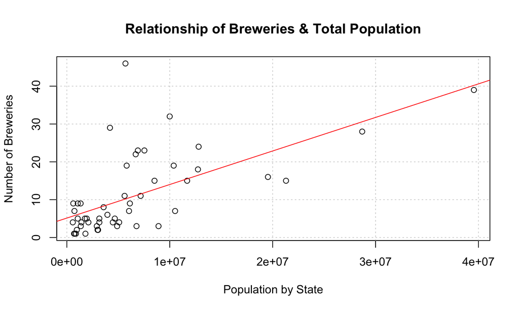

## Additional Analysis : 2018 Census Data on https://www.census.gov

-Examining correlation between number of breweries and median alcohol content

```
##   State Alcohol_content Bitterness numBreweries
## 1    AK          0.0560       46.0            7
## 2    AL          0.0600       43.0            3
## 3    AR          0.0520       39.0            2
## 4    AZ          0.0550       20.5           11
## 5    CA          0.0580       42.0           39
## 6    CO          0.0605       40.0           46
```

## Plotting the correlation between number of breweries and median alcohol content

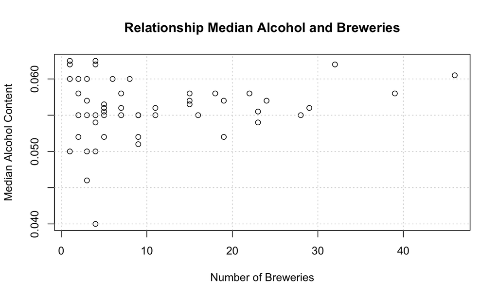

## Additional Analysis : 2018 Census Data on https://www.census.gov

-Examining correlation between population and median alcohol content

```
##   State Alcohol_content Bitterness numBreweries  StateFull Population
## 1    AK          0.0560       46.0            7     Alaska     737438
## 2    AL          0.0600       43.0            3    Alabama    4887871
## 3    AR          0.0520       39.0            2   Arkansas    3013825
## 4    AZ          0.0550       20.5           11    Arizona    7171646
## 5    CA          0.0580       42.0           39 California   39557045
## 6    CO          0.0605       40.0           46   Colorado    5695564
```

## Plotting the correlation between population and median alcohol content

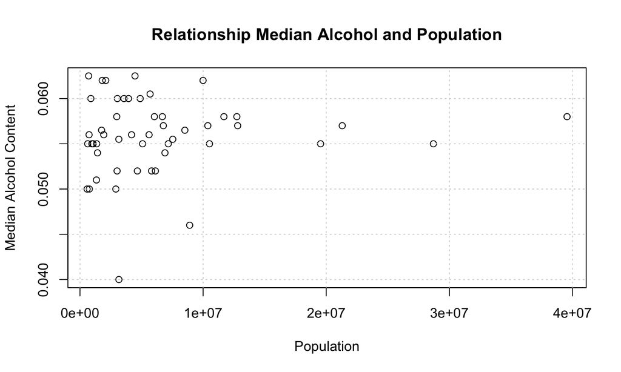

## Most popular beer style in the US

Most popular beer style in the US: American IPA.

```
## # A tibble: 1 x 2
##   Style            n
##   <fct>        <int>
## 1 American IPA   424
```

## Most popular beer name in the US

Most popular beer name in the US: Nonstop Hef Hop

```
## # A tibble: 1 x 2
##   Name                n
##   <fct>           <int>
## 1 Nonstop Hef Hop    12
```

## Conclusion 1

-The style of beer that we would recommend will be American IPA. We found American IPA to be the most popular style

-The name of the beer that we will recommend will be Nonstop Hef Hop. We found Nonstop Hef Hop to be the most popular beer name

-According to our statistic summary from ABV and IBU , for an average ABV beer at 0.06 the recommended IBU is roughly 40.

-We will recommend to target the states with less breweries regardless of the population, because we did not find any strong correlation between the population and the amount of breweries